# RNA-Seq Analysis

Geraldine San Ramon

4/28/2022

### Get the data after featureCounts.

```r
#Load the 6 sample data counts
DMSO_REP1 <- read.delim("DMSO-REP1.tabular", check.names=FALSE, stringsAsFactors=FALSE)
DMSO_REP2 <- read.delim("DMSO-REP2.tabular", check.names=FALSE, stringsAsFactors=FALSE)
DMSO_REP3 <- read.delim("DMSO-REP3.tabular", check.names=FALSE, stringsAsFactors=FALSE)
RA_REP1 <- read.delim("RA-REP1.tabular", check.names=FALSE, stringsAsFactors=FALSE)
RA_REP2 <- read.delim("RA-REP2.tabular", check.names=FALSE, stringsAsFactors=FALSE)
RA_REP3 <- read.delim("RA-REP3.tabular", check.names=FALSE, stringsAsFactors=FALSE)

#merge in one table
counts.data <- merge(merge(merge(merge(merge(
  DMSO_REP1,
  DMSO_REP2, all = TRUE),
  DMSO_REP3, all = TRUE),
  RA_REP1, all = TRUE),
  RA_REP2, all = TRUE),
  RA_REP3, all = TRUE)
```

### Prepare table for ensmbl to get the gene names of ensembl id (Geneid)

```r
#Remove number after the dot in ensembl id (Geneid)
counts.data$ensemblID <- gsub('\\..*', '', counts.data$Geneid)
head(counts.data)
```

```
##                  Geneid DMSO_REP1 DMSO_REP2 DMSO_REP3 RA_REP1 RA_REP2 RA_REP3
## 1  ENSMUSG00000000001.4      2456      2051      2147    2087     491    1191
## 2 ENSMUSG00000000003.15         0         0         0       0       0       0
## 3 ENSMUSG00000000028.14      1524      1297      1126    1228     238     786
## 4 ENSMUSG00000000031.15      3066      2765      2237    3683     821    2006
## 5 ENSMUSG00000000037.16        41        29        25      39      11      34
## 6 ENSMUSG00000000049.11         0         0         0       0       0       0
##            ensemblID
## 1 ENSMUSG00000000001
## 2 ENSMUSG00000000003
## 3 ENSMUSG00000000028
## 4 ENSMUSG00000000031
## 5 ENSMUSG00000000037
## 6 ENSMUSG00000000049
```

### Get Gene names

```r
library(biomaRt)

#convert ensmbl id to gene name
ensembl_ids <- counts.data$ensemblID
ensembl <- useEnsembl(biomart = "ensembl", dataset="mmusculus_gene_ensembl")
gene_symbol <- getBM(attributes=c('ensembl_gene_id', 'external_gene_name', 'description'),filters = 'ensembl_gene_id', values = ensembl_ids, mart = ensembl)

head(gene_symbol)
```

```
##      ensembl_gene_id external_gene_name
## 1 ENSMUSG00000000001              Gnai3
## 2 ENSMUSG00000000003               Pbsn
## 3 ENSMUSG00000000028              Cdc45
## 4 ENSMUSG00000000031                H19
## 5 ENSMUSG00000000037              Scml2
## 6 ENSMUSG00000000049               Apoh
##                                                                                            description
## 1 guanine nucleotide binding protein (G protein), alpha inhibiting 3 [Source:MGI Symbol;Acc:MGI:95773]
## 2                                                         probasin [Source:MGI Symbol;Acc:MGI:1860484]
## 3                                           cell division cycle 45 [Source:MGI Symbol;Acc:MGI:1338073]
## 4                     H19, imprinted maternally expressed transcript [Source:MGI Symbol;Acc:MGI:95891]
## 5                                Scm polycomb group protein like 2 [Source:MGI Symbol;Acc:MGI:1340042]
## 6                                                   apolipoprotein H [Source:MGI Symbol;Acc:MGI:88058]
```

```r
#Merge
counts.data.gene <- merge(counts.data, gene_symbol, by.x="ensemblID", by.y="ensembl_gene_id", all.x = TRUE, all.y= FALSE, sort=FALSE)
colnames(counts.data.gene)[9] <- 'gene_name'
dim(counts.data.gene)
```

```
## [1] 48440    10
```

```r
head(counts.data.gene)
```

```
##            ensemblID                Geneid DMSO_REP1 DMSO_REP2 DMSO_REP3
## 1 ENSMUSG00000000001  ENSMUSG00000000001.4      2456      2051      2147
## 2 ENSMUSG00000000003 ENSMUSG00000000003.15         0         0         0
## 3 ENSMUSG00000000028 ENSMUSG00000000028.14      1524      1297      1126
## 4 ENSMUSG00000000031 ENSMUSG00000000031.15      3066      2765      2237
## 5 ENSMUSG00000000037 ENSMUSG00000000037.16        41        29        25
## 6 ENSMUSG00000000049 ENSMUSG00000000049.11         0         0         0
##   RA_REP1 RA_REP2 RA_REP3 gene_name
## 1    2087     491    1191     Gnai3
## 2       0       0       0      Pbsn
## 3    1228     238     786     Cdc45
## 4    3683     821    2006       H19
## 5      39      11      34     Scml2
## 6       0       0       0      Apoh
##                                                                                            description
## 1 guanine nucleotide binding protein (G protein), alpha inhibiting 3 [Source:MGI Symbol;Acc:MGI:95773]
## 2                                                         probasin [Source:MGI Symbol;Acc:MGI:1860484]
## 3                                           cell division cycle 45 [Source:MGI Symbol;Acc:MGI:1338073]
## 4                     H19, imprinted maternally expressed transcript [Source:MGI Symbol;Acc:MGI:95891]
## 5                                Scm polycomb group protein like 2 [Source:MGI Symbol;Acc:MGI:1340042]
## 6                                                   apolipoprotein H [Source:MGI Symbol;Acc:MGI:88058]
```

```r
#write.csv(counts.data.gene, 'counts.data.gene.csv')
```

### Format count data to only have the counts

```r
#make row names the ensemble id
counts <- counts.data.gene
rownames(counts) <- counts.data.gene$ensemblID

#remove geneid column
counts.only <- counts[,3:8]
head(counts.only)
```

```
##                    DMSO_REP1 DMSO_REP2 DMSO_REP3 RA_REP1 RA_REP2 RA_REP3
## ENSMUSG00000000001      2456      2051      2147    2087     491    1191
## ENSMUSG00000000003         0         0         0       0       0       0
## ENSMUSG00000000028      1524      1297      1126    1228     238     786
## ENSMUSG00000000031      3066      2765      2237    3683     821    2006
## ENSMUSG00000000037        41        29        25      39      11      34
## ENSMUSG00000000049         0         0         0       0       0       0
```

### Cretae a DGElist object

```r
library(edgeR)
group <- factor(c("DMSO","DMSO","DMSO","RA","RA","RA"))
y <- DGEList(counts=counts.only, group=group, genes = counts.data.gene$gene_name)
y
```

```
## An object of class "DGEList"
## $counts
##                    DMSO_REP1 DMSO_REP2 DMSO_REP3 RA_REP1 RA_REP2 RA_REP3
## ENSMUSG00000000001      2456      2051      2147    2087     491    1191
## ENSMUSG00000000003         0         0         0       0       0       0
## ENSMUSG00000000028      1524      1297      1126    1228     238     786
## ENSMUSG00000000031      3066      2765      2237    3683     821    2006
## ENSMUSG00000000037        41        29        25      39      11      34
## 48435 more rows ...
##
## $samples
##           group lib.size norm.factors
## DMSO_REP1  DMSO 21790332            1
## DMSO_REP2  DMSO 20313583            1
## DMSO_REP3  DMSO 18374478            1
## RA_REP1      RA 21506090            1
## RA_REP2      RA  7696756            1
## RA_REP3      RA 16950496            1
##
## $genes
##                    genes
## ENSMUSG00000000001 Gnai3
## ENSMUSG00000000003  Pbsn
## ENSMUSG00000000028 Cdc45
## ENSMUSG00000000031   H19
## ENSMUSG00000000037 Scml2
## 48435 more rows ...
```

Filter out lowly expressed genes

```r
#Get counts per million
myCPM <- cpm(counts.only)
head(myCPM)
```

```
##                     DMSO_REP1  DMSO_REP2  DMSO_REP3   RA_REP1    RA_REP2
## ENSMUSG00000000001 112.710536 100.966924 116.846857  97.04228  63.793110
## ENSMUSG00000000003   0.000000   0.000000   0.000000   0.00000   0.000000
## ENSMUSG00000000028  69.939274  63.848903  61.280652  57.10011  30.922118
## ENSMUSG00000000031 140.704602 136.115820 121.744955 171.25382 106.668316
## ENSMUSG00000000037   1.881568   1.427616   1.360583   1.81344   1.429174
## ENSMUSG00000000049   0.000000   0.000000   0.000000   0.00000   0.000000
##                       RA_REP3
## ENSMUSG00000000001  70.263431
## ENSMUSG00000000003   0.000000
## ENSMUSG00000000028  46.370325
## ENSMUSG00000000031 118.344620
## ENSMUSG00000000037   2.005841
## ENSMUSG00000000049   0.000000
```

Set threshold to 0.5 which is ~10-15 counts

```r
#values > 0.5
thresh <- myCPM > 0.5
head(thresh)
```

```
##                    DMSO_REP1 DMSO_REP2 DMSO_REP3 RA_REP1 RA_REP2 RA_REP3
## ENSMUSG00000000001      TRUE      TRUE      TRUE    TRUE    TRUE    TRUE
## ENSMUSG00000000003     FALSE     FALSE     FALSE   FALSE   FALSE   FALSE
## ENSMUSG00000000028      TRUE      TRUE      TRUE    TRUE    TRUE    TRUE
## ENSMUSG00000000031      TRUE      TRUE      TRUE    TRUE    TRUE    TRUE
## ENSMUSG00000000037      TRUE      TRUE      TRUE    TRUE    TRUE    TRUE
## ENSMUSG00000000049     FALSE     FALSE     FALSE   FALSE   FALSE   FALSE
```

How many genes pass the threshold

```r
table(rowSums(thresh))
```

```
##
##     0     1     2     3     4     5     6
## 28217  1234   823   829   697  1092 15548
```

Keep genes where threshold is true for 3 rows (3 replicates)

```r
keep <- rowSums(thresh) >= 3
summary(keep)
```

```
##    Mode   FALSE    TRUE
## logical   30274   18166
```

There are 18,166 genes that passed the threshold.

Check counts vs cpm for sample 1 (DMSO-REP1)

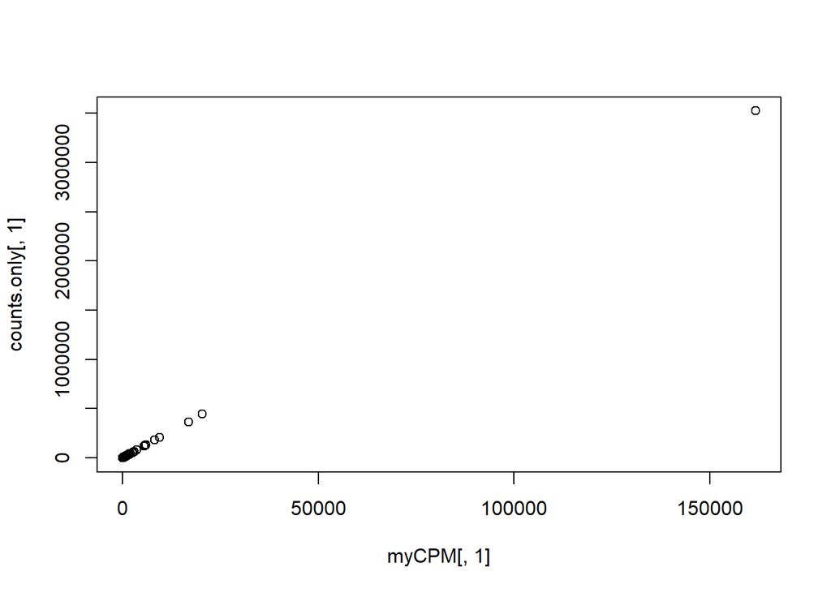

```r
plot(myCPM[,1],counts.only[,1])
```

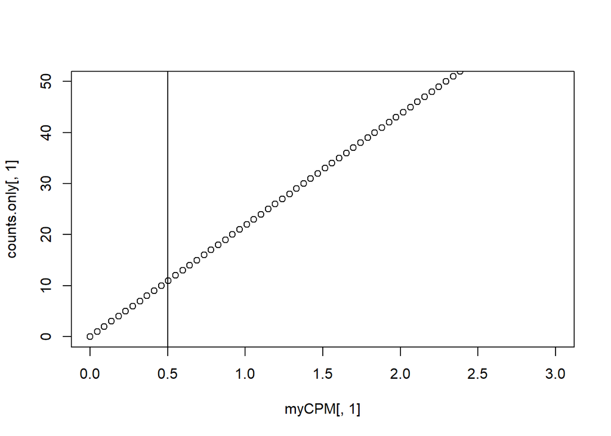

```r
# Zoom in
plot(myCPM[,1],counts.only[,1],ylim=c(0,50),xlim=c(0,3))
# Add a vertical line at 0.5 CPM
abline(v=0.5)
```

Keep genes that pass threshold only

```r
y <- y[keep, keep.lib.sizes=FALSE]
#check how many reads for each sample
y$samples
```

```
##           group lib.size norm.factors
## DMSO_REP1  DMSO 21753883            1
## DMSO_REP2  DMSO 20278526            1
## DMSO_REP3  DMSO 18345424            1
## RA_REP1      RA 21467320            1
## RA_REP2      RA  7685230            1
## RA_REP3      RA 16910830            1
```

Check descrepencies b/w samples

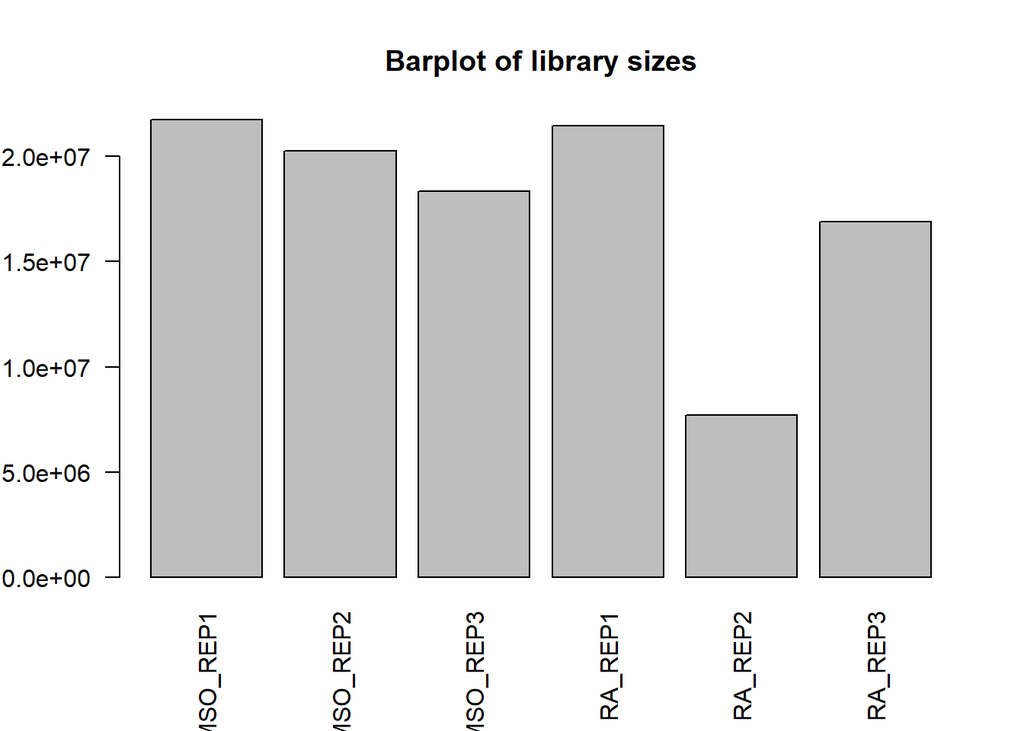

```r
barplot(y$samples$lib.size,names=colnames(y),las=2)
title("Barplot of library sizes")
```

RA-REP2 have very low counts.

#Log counts per million

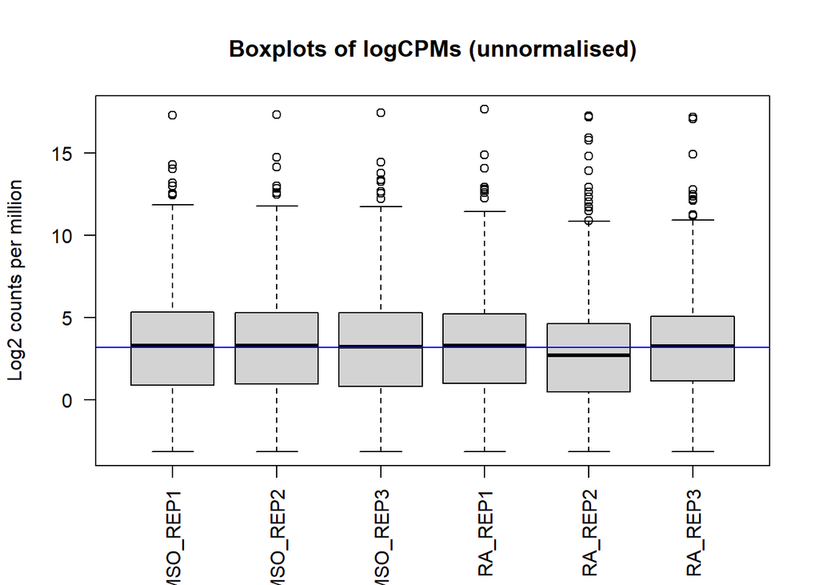

```r
# Get log2 counts per million
logcounts <- cpm(y,log=TRUE)
# Check distributions of samples using boxplots
boxplot(logcounts, xlab="", ylab="Log2 counts per million",las=2)
# Add a blue horizontal line that corresponds to the median logCPM
abline(h=median(logcounts),col="blue")
title("Boxplots of logCPMs (unnormalised)")
```

Check variation in data

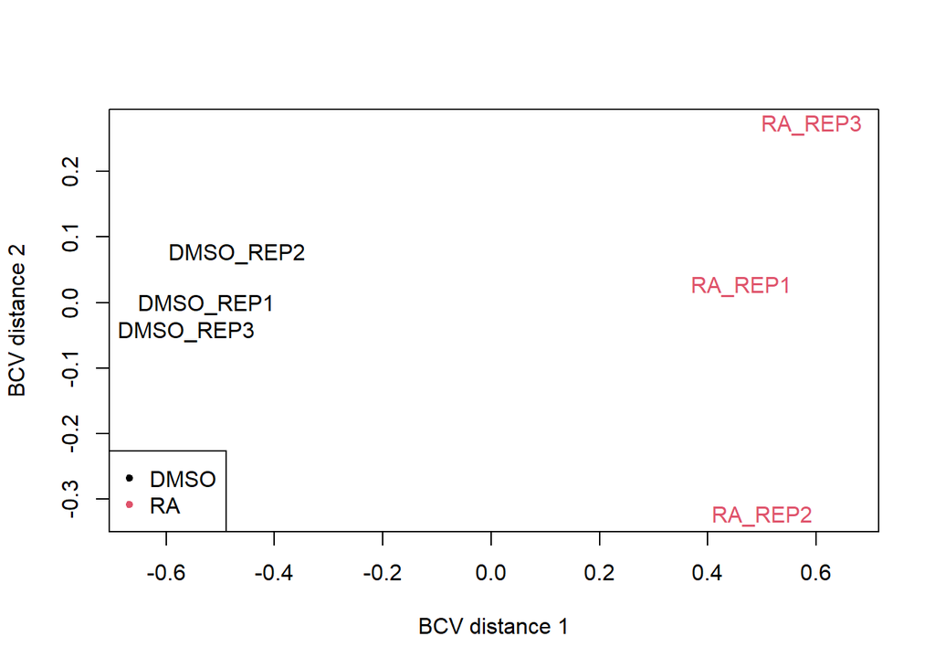

```r
plotMDS(y, method="bcv", col=as.numeric(y$samples$group))
legend("bottomleft", as.character(unique(y$samples$group)), col=1:3, pch=20)
```

The 2 groups (DMSO & RA) are separated well. Although RA samples are scattered.

```r
# Estimate the variance for each row in the logcounts matrix
var_genes <- apply(logcounts, 1, var)
head(var_genes)
```

```
## ENSMUSG00000000001 ENSMUSG00000000028 ENSMUSG00000000031 ENSMUSG00000000037
##         0.13118372         0.18489850         0.05664524         0.05206531
## ENSMUSG00000000056 ENSMUSG00000000078
##         0.16105225         0.17478566
```

Get the top 100 most variable genes

```r
select_var <- names(sort(var_genes, decreasing=TRUE))[1:100]
head(select_var)
```

```
## [1] "ENSMUSG00000106106" "ENSMUSG00000076258" "ENSMUSG00000024987"
## [4] "ENSMUSG00000098973" "ENSMUSG00000035202" "ENSMUSG00000086324"
```

```r
# Subset logcounts matrix
highly_variable_lcpm <- logcounts[select_var,]
dim(highly_variable_lcpm)
```

```
## [1] 100   6
```

```r
head(highly_variable_lcpm, 10)
```

```
##                    DMSO_REP1 DMSO_REP2  DMSO_REP3   RA_REP1     RA_REP2
## ENSMUSG00000106106  7.368355  5.705633  7.7924248 7.3733560 17.21348286
## ENSMUSG00000076258  4.732853  5.322186  4.3613331 4.1050484 13.94520167
## ENSMUSG00000024987 -3.148951 -3.148951 -2.5799412 4.2847381  3.65583595
## ENSMUSG00000098973  4.572081  2.456249  3.8419446 5.1294056 12.92889878
## ENSMUSG00000035202  7.355049  5.438308  8.5380102 7.6262612 14.82677959
## ENSMUSG00000086324  5.945303  3.642743  7.7345221 6.1725108 12.65433008
## ENSMUSG00000048752 -1.057426 -1.126798 -0.7289958 4.2603983  3.51515124
## ENSMUSG00000028444 -1.363824 -1.291176 -1.3759993 3.2513234  3.26475798
## ENSMUSG00000032327 -1.363824 -1.939659 -2.1729468 3.2442485  2.05187627
## ENSMUSG00000004359  5.140732  5.099582  5.4008308 0.8767923  0.03361839
##                      RA_REP3
## ENSMUSG00000106106  9.164771
## ENSMUSG00000076258 10.114797
## ENSMUSG00000024987  3.896869
## ENSMUSG00000098973  4.451141
## ENSMUSG00000035202  7.445599
## ENSMUSG00000086324  5.732151
## ENSMUSG00000048752  4.074469
## ENSMUSG00000028444  3.885369
## ENSMUSG00000032327  3.370564
## ENSMUSG00000004359  0.773446
```

The 2 top genes show that RA-Replicate2 has very high spike compared to the other samples and to the other 2 replicates. Same with genes 4-6 (ENSMUSG00000098973, ENSMUSG00000035202 and ENSMUSG00000086324).

So I went back to FastQC of RA_REP2. This replicate has a lot of overrepresnted sequences that may explain this. It’s also possible that this sample is contaminated. So I’m going to remove this from the analysis and re-analyze without RA-REP2.

### Create another DEGlist without RA-REP2

```r
counts.only.2 <- counts.only[,c(1:4,6)]
head(counts.only.2)
```

```
##                    DMSO_REP1 DMSO_REP2 DMSO_REP3 RA_REP1 RA_REP3
## ENSMUSG00000000001      2456      2051      2147    2087    1191
## ENSMUSG00000000003         0         0         0       0       0
## ENSMUSG00000000028      1524      1297      1126    1228     786
## ENSMUSG00000000031      3066      2765      2237    3683    2006
## ENSMUSG00000000037        41        29        25      39      34
## ENSMUSG00000000049         0         0         0       0       0
```

```r
group2 <- factor(c("DMSO","DMSO","DMSO","RA","RA"))
y2 <- DGEList(counts=counts.only.2, group=group2, genes = counts.data.gene$gene_name)
y2
```

```
## An object of class "DGEList"
## $counts
##                    DMSO_REP1 DMSO_REP2 DMSO_REP3 RA_REP1 RA_REP3
## ENSMUSG00000000001      2456      2051      2147    2087    1191
## ENSMUSG00000000003         0         0         0       0       0
## ENSMUSG00000000028      1524      1297      1126    1228     786
## ENSMUSG00000000031      3066      2765      2237    3683    2006
## ENSMUSG00000000037        41        29        25      39      34
## 48435 more rows ...
##
## $samples
##           group lib.size norm.factors
## DMSO_REP1  DMSO 21790332            1
## DMSO_REP2  DMSO 20313583            1
## DMSO_REP3  DMSO 18374478            1
## RA_REP1      RA 21506090            1
## RA_REP3      RA 16950496            1
##
## $genes
##                    genes
## ENSMUSG00000000001 Gnai3
## ENSMUSG00000000003  Pbsn
## ENSMUSG00000000028 Cdc45
## ENSMUSG00000000031   H19
## ENSMUSG00000000037 Scml2
## 48435 more rows ...
```

### Counts per million

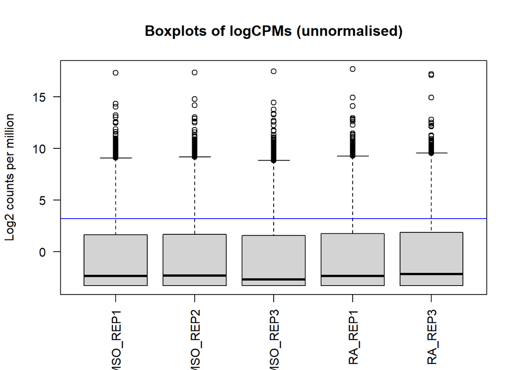

```r
# Get log2 counts per million
logcounts2 <- cpm(y2, log=TRUE)
# Check distributions of samples using boxplots
boxplot(logcounts2, xlab="", ylab="Log2 counts per million", las=2)
# add a blue horizontal line that corresponds to the median logCPM
abline(h=median(logcounts),col="blue")
title("Boxplots of logCPMs (unnormalised)")
```

Check variation in data

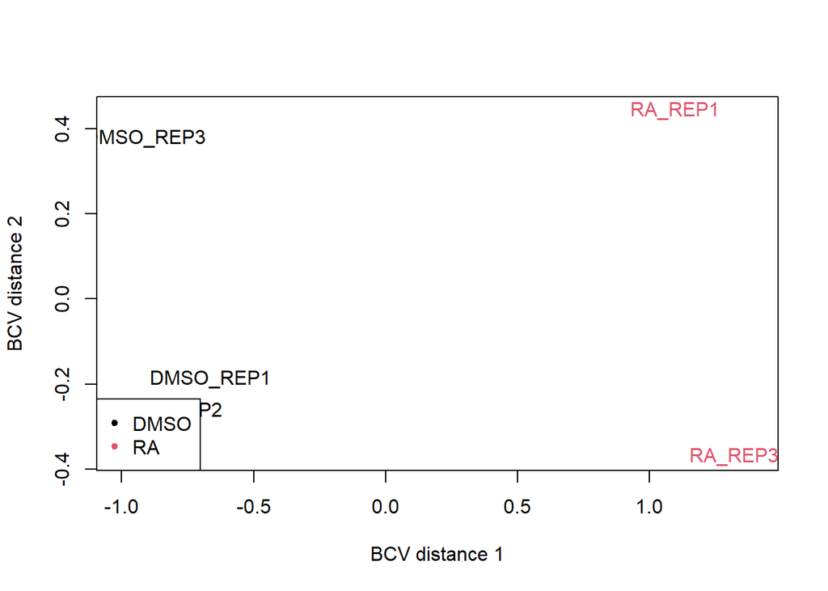

```r
plotMDS(y2, method="bcv", col=as.numeric(y2$samples$group))
legend("bottomleft", as.character(unique(y2$samples$group)), col=1:3, pch=20)
```

The 2 groups are separated well.

```r
# We estimate the variance for each row in the logcounts matrix
var_genes2 <- apply(logcounts2, 1, var)
head(var_genes2)
```

```
## ENSMUSG00000000001 ENSMUSG00000000003 ENSMUSG00000000028 ENSMUSG00000000031
##         0.08419903         0.00000000         0.04959918         0.04459819
## ENSMUSG00000000037 ENSMUSG00000000049
##         0.05586005         0.00000000
```

Get the top 100 most variable genes

```r
select_var2 <- names(sort(var_genes2, decreasing=TRUE))[1:100]
head(select_var2)
```

```
## [1] "ENSMUSG00000024987" "ENSMUSG00000032327" "ENSMUSG00000048752"
## [4] "ENSMUSG00000049719" "ENSMUSG00000028444" "ENSMUSG00000027400"
```

```r
# Subset logcounts matrix
highly_variable_lcpm_2 <- logcounts2[select_var2,]
dim(highly_variable_lcpm_2)
```

```
## [1] 100   5
```

```r
head(highly_variable_lcpm_2, 10)
```

```
##                     DMSO_REP1  DMSO_REP2  DMSO_REP3  RA_REP1   RA_REP3
## ENSMUSG00000024987 -3.3064810 -3.3064810 -2.6850157 4.281285  3.892382
## ENSMUSG00000032327 -1.4095546 -2.0071685 -2.2520674 3.239897  3.365590
## ENSMUSG00000048752 -1.0947671 -1.1659412 -0.7590478 4.256931  4.070110
## ENSMUSG00000049719 -3.3064810 -3.3064810 -3.3064810 1.861939  1.581036
## ENSMUSG00000028444 -1.4095546 -1.3348064 -1.4220062 3.246980  3.880873
## ENSMUSG00000027400 -0.5193808 -3.3064810 -2.2520674 2.369999  2.527227
## ENSMUSG00000029848  1.4173924  0.7871022  0.7939172 5.922247  5.586893
## ENSMUSG00000024427  1.9154936  2.0827842  1.5514364 6.466001  6.519177
## ENSMUSG00000001622 -3.3064810 -2.7340389 -2.6850157 1.843365  1.581036
## ENSMUSG00000076258  4.7298144  5.3192797  4.3582426 4.101483 10.111402
```

Apply normalisation

```r
y2 <- calcNormFactors(y2)
y2$samples
```

```
##           group lib.size norm.factors
## DMSO_REP1  DMSO 21790332    1.0375106
## DMSO_REP2  DMSO 20313583    1.0320548
## DMSO_REP3  DMSO 18374478    0.9827157
## RA_REP1      RA 21506090    0.9894757
## RA_REP3      RA 16950496    0.9604433
```

Use voom to transform data into log counts per million. Will use logCPM instead of counts.

```r
design <- model.matrix(~group2, data=y2$samples)
colnames(design) <- levels(y2$samples$group)
design
```

```
##           DMSO RA
## DMSO_REP1    1  0
## DMSO_REP2    1  0
## DMSO_REP3    1  0
## RA_REP1      1  1
## RA_REP3      1  1
## attr(,"assign")
## [1] 0 1
## attr(,"contrasts")
## attr(,"contrasts")$group2
## [1] "contr.treatment"
```

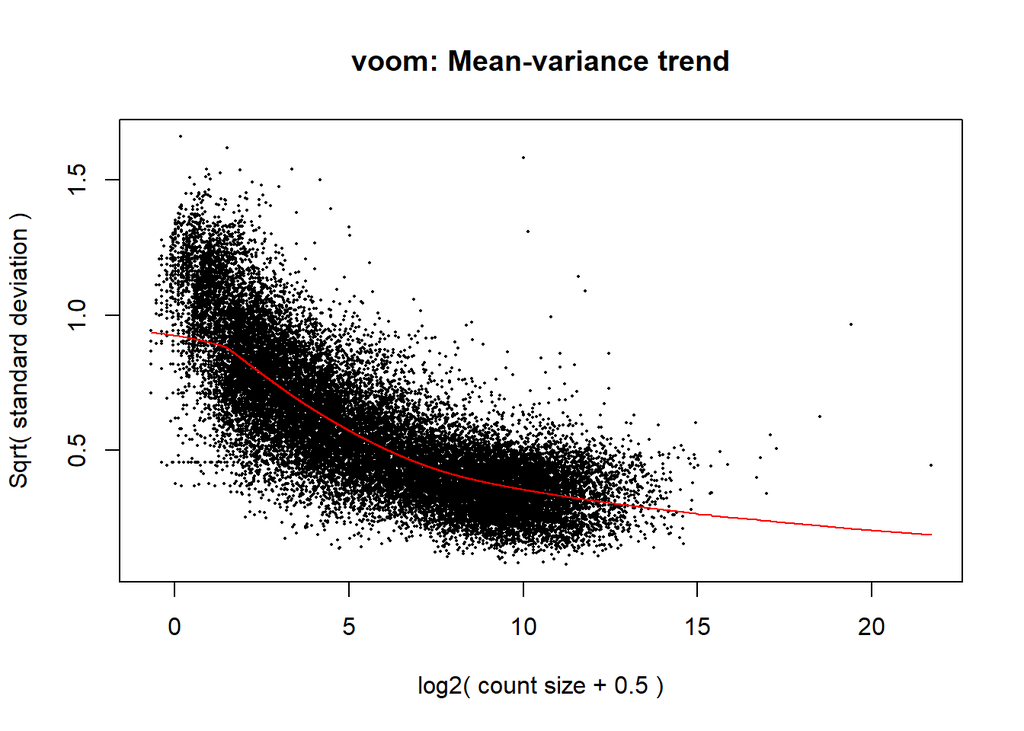

```r
v <- voom(y2, design, plot = TRUE)
```

```r
v
```

```
## An object of class "EList"
## $genes
##                    genes
## ENSMUSG00000000001 Gnai3
## ENSMUSG00000000003  Pbsn
## ENSMUSG00000000028 Cdc45
## ENSMUSG00000000031   H19
## ENSMUSG00000000037 Scml2
## 48435 more rows ...
##
## $targets
##           group lib.size norm.factors
## DMSO_REP1  DMSO 22607700    1.0375106
## DMSO_REP2  DMSO 20964730    1.0320548
## DMSO_REP3  DMSO 18056887    0.9827157
## RA_REP1      RA 21279753    0.9894757
## RA_REP3      RA 16279990    0.9604433
##
## $E
##                    DMSO_REP1  DMSO_REP2 DMSO_REP3    RA_REP1   RA_REP3
## ENSMUSG00000000001  6.763646  6.6125710  6.893965  6.6161509  6.193535
## ENSMUSG00000000003 -5.498742 -5.3898924 -5.174477 -5.4114096 -5.025028
## ENSMUSG00000000028  6.075378  5.9516264  5.963154  5.8512726  5.594275
## ENSMUSG00000000031  7.083635  7.0434322  6.953195  7.4354520  6.945437
## ENSMUSG00000000037  0.876297  0.4927506  0.497948  0.8923712  1.083496
## 48435 more rows ...
##
## $weights
##           [,1]      [,2]      [,3]      [,4]      [,5]
## [1,] 88.202917 85.881955 81.443470 79.158690 71.840015
## [2,]  1.308062  1.308062  1.308062  1.308062  1.308062
## [3,] 73.035182 71.059167 67.259373 66.615973 60.246785
## [4,] 94.174850 91.719776 87.036742 95.903506 87.341070
## [5,]  9.918926  9.394556  8.435074 11.391350  9.398058
## 48435 more rows ...
##
## $design
##           DMSO RA
## DMSO_REP1    1  0
## DMSO_REP2    1  0
## DMSO_REP3    1  0
## RA_REP1      1  1
## RA_REP3      1  1
## attr(,"assign")
## [1] 0 1
## attr(,"contrasts")
## attr(,"contrasts")$group2
## [1] "contr.treatment"
```

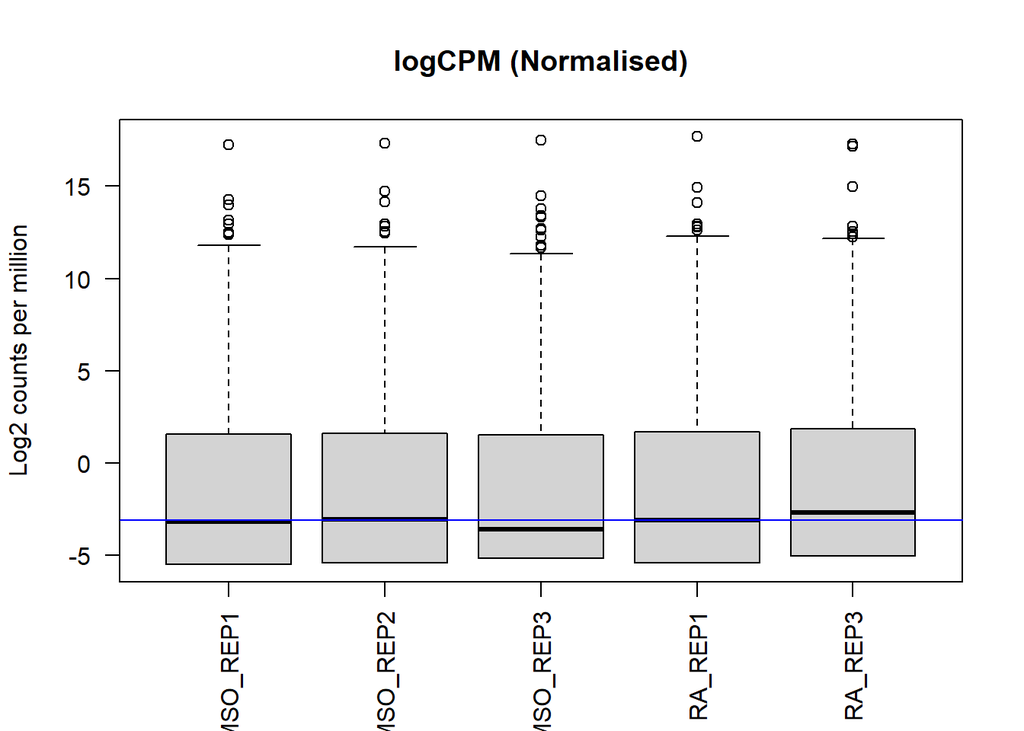

```r
boxplot(v$E, xlab="", ylab="Log2 counts per million",las=2,main="logCPM (Normalised)")
#blue horizontal line that corresponds to the median logCPM
abline(h=median(v$E),col="blue")
```

```r
fit1 <- lmFit(v)
fit1 <- eBayes(fit1)
topTable(fit1,coef=2,30)
```

```
##                       genes     logFC   AveExpr         t      P.Value
## ENSMUSG00000031548    Sfrp1 -1.885837  7.240285 -44.04980 7.089651e-08
## ENSMUSG00000031169    Porcn  2.899232  4.621287  47.86979 4.610644e-08
## ENSMUSG00000032125    Robo4  3.872533  3.921794  52.39261 2.889606e-08
## ENSMUSG00000030067    Foxp1  3.318838  3.453633  43.85313 7.255668e-08
## ENSMUSG00000022012    Enox1  2.329318  4.937639  37.66457 1.593280e-07
## ENSMUSG00000001507    Itga3  1.419134  7.159710  36.28424 1.932361e-07
## ENSMUSG00000020661   Dnmt3a  1.703915  6.312158  36.33896 1.917372e-07
## ENSMUSG00000037035    Inhbb  2.347857  4.124574  38.22077 1.477019e-07
## ENSMUSG00000026389   Steap3  1.842341  5.280960  36.13418 1.974188e-07
## ENSMUSG00000030306    Tmtc1  3.229471  4.696373  36.09255 1.985982e-07
## ENSMUSG00000024427    Spry4  4.722486  3.687841  38.99391 1.331765e-07
## ENSMUSG00000035158     Mitf -2.478984  5.405807 -35.62249 2.125157e-07
## ENSMUSG00000021835     Bmp4  2.443737  3.899490  36.17771 1.961944e-07
## ENSMUSG00000022094 Slc39a14  4.049187  4.167029  35.93822 2.030444e-07
## ENSMUSG00000030310   Slc6a1  2.129786  4.288408  35.05295 2.309688e-07
## ENSMUSG00000039115    Itga9  2.207185  4.375668  31.50253 4.009096e-07
## ENSMUSG00000040430  Pitpnc1  1.621359  5.977129  30.41308 4.807589e-07
## ENSMUSG00000027070     Lrp2  1.642578  7.806439  30.11303 5.059928e-07
## ENSMUSG00000020183      Cpm  3.367709  2.362874  34.59947 2.470394e-07
## ENSMUSG00000041817  Fam169a  1.198550  7.112234  29.22429 5.905537e-07
## ENSMUSG00000032232    Cgnl1  2.793691  5.111914  28.87030 6.288636e-07
## ENSMUSG00000001288     Rarg  1.591507  6.377656  28.73585 6.441851e-07
## ENSMUSG00000031555    Adam9  1.171583  6.591471  28.65837 6.532168e-07
## ENSMUSG00000019989    Enpp3  2.643565  4.672651  28.42143 6.817886e-07
## ENSMUSG00000041075     Fzd7  1.634895  5.552974  27.37916 8.266011e-07
## ENSMUSG00000071176 Arhgef10  2.344343  3.150631  28.24429 7.041248e-07
## ENSMUSG00000038305  Spats2l -2.103197  3.516607 -28.46346 6.766130e-07
## ENSMUSG00000015653   Steap2  1.997152  5.595821  26.24107 1.028737e-06
## ENSMUSG00000026380  Tfcp2l1 -1.438129 10.002542 -26.61871 9.557308e-07
## ENSMUSG00000069114   Zbtb10 -1.406843  5.853339 -25.80029 1.122532e-06
##                       adj.P.Val        B
## ENSMUSG00000031548 0.0007353045 9.245698
## ENSMUSG00000031169 0.0007353045 9.231801
## ENSMUSG00000032125 0.0007353045 9.173041
## ENSMUSG00000030067 0.0007353045 8.508871
## ENSMUSG00000022012 0.0007353045 8.397809
## ENSMUSG00000001507 0.0007353045 8.388750
## ENSMUSG00000020661 0.0007353045 8.362591
## ENSMUSG00000037035 0.0007353045 8.307998
## ENSMUSG00000026389 0.0007353045 8.258991
## ENSMUSG00000030306 0.0007353045 8.174869
## ENSMUSG00000024427 0.0007353045 8.113334
## ENSMUSG00000035158 0.0007353045 8.085701
## ENSMUSG00000021835 0.0007353045 8.044522
## ENSMUSG00000022094 0.0007353045 8.025816
## ENSMUSG00000030310 0.0007458751 8.000165
## ENSMUSG00000039115 0.0011423565 7.555644
## ENSMUSG00000040430 0.0012181359 7.485272
## ENSMUSG00000027070 0.0012181359 7.426350
## ENSMUSG00000020183 0.0007479119 7.301492
## ENSMUSG00000041817 0.0012181359 7.282075
## ENSMUSG00000032232 0.0012181359 7.203773
## ENSMUSG00000001288 0.0012181359 7.200558
## ENSMUSG00000031555 0.0012181359 7.185667
## ENSMUSG00000019989 0.0012181359 7.106599
## ENSMUSG00000041075 0.0013001498 6.950408
## ENSMUSG00000071176 0.0012181359 6.897152
## ENSMUSG00000038305 0.0012181359 6.815347
## ENSMUSG00000015653 0.0014656484 6.733625
## ENSMUSG00000026380 0.0014270298 6.674031
## ENSMUSG00000069114 0.0015104289 6.646205
```

## Heatmap

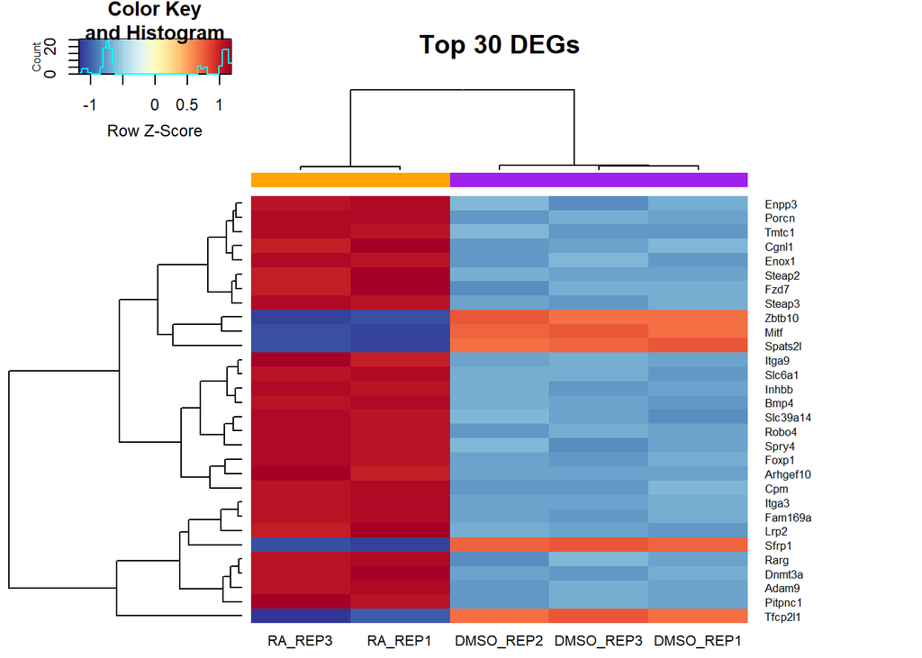

```r
library(gplots)
library(RColorBrewer)
mypalette <- brewer.pal(11,"RdYlBu")
morecols <- colorRampPalette(mypalette)
# Set up colour vector for celltype variable
col.cell <- c("purple","orange")[group2]

top.30 <- topTable(fit1,coef=2,30)
top.30.idx <- match(rownames(top.30), rownames(v$E))
top.30.cpm <- v$E[top.30.idx,]
top.30.df <- merge(top.30, top.30.cpm, by=0, all.x = TRUE, all.y= FALSE, sort=FALSE)

heatmap.2(as.matrix(top.30.df[,9:13]), col=rev(morecols(50)), trace="none", main="Top 30 DEGs", ColSideColors=col.cell, scale="row", margins=c(2,10), labRow=top.30.df$genes, cexRow = 0.8, cexCol = 1, srtCol=0, adjCol = c(0.5,0.5))
```

Count the number of genes with FDR < 5%

```r
results <- topTable(fit1, coef=2, number = nrow(y2$counts), sort.by = "p")
head(results)
```

```
##                    genes     logFC  AveExpr         t      P.Value    adj.P.Val
## ENSMUSG00000032125 Robo4  3.872533 3.921794  52.39261 2.889606e-08 0.0007353045
## ENSMUSG00000031169 Porcn  2.899232 4.621287  47.86979 4.610644e-08 0.0007353045
## ENSMUSG00000031548 Sfrp1 -1.885837 7.240285 -44.04980 7.089651e-08 0.0007353045
## ENSMUSG00000030067 Foxp1  3.318838 3.453633  43.85313 7.255668e-08 0.0007353045
## ENSMUSG00000024427 Spry4  4.722486 3.687841  38.99391 1.331765e-07 0.0007353045
## ENSMUSG00000037035 Inhbb  2.347857 4.124574  38.22077 1.477019e-07 0.0007353045
##                           B
## ENSMUSG00000032125 9.173041
## ENSMUSG00000031169 9.231801
## ENSMUSG00000031548 9.245698
## ENSMUSG00000030067 8.508871
## ENSMUSG00000024427 8.113334
## ENSMUSG00000037035 8.307998
```

```r
sum(results$adj.P.Val < .05)
```

```
## [1] 3195
```

3195 genes have 5%FDR.

### Differential expression using edgeR

```r
group2 <- factor(c("DMSO","DMSO","DMSO","RA","RA"))
y2e <- DGEList(counts=counts.only.2, group=group2, genes = counts.data.gene$gene_name)
y2e
```

```
## An object of class "DGEList"
## $counts
##                    DMSO_REP1 DMSO_REP2 DMSO_REP3 RA_REP1 RA_REP3
## ENSMUSG00000000001      2456      2051      2147    2087    1191
## ENSMUSG00000000003         0         0         0       0       0
## ENSMUSG00000000028      1524      1297      1126    1228     786
## ENSMUSG00000000031      3066      2765      2237    3683    2006
## ENSMUSG00000000037        41        29        25      39      34
## 48435 more rows ...
##
## $samples
##           group lib.size norm.factors
## DMSO_REP1  DMSO 21790332            1
## DMSO_REP2  DMSO 20313583            1
## DMSO_REP3  DMSO 18374478            1
## RA_REP1      RA 21506090            1
## RA_REP3      RA 16950496            1
##
## $genes
##                    genes
## ENSMUSG00000000001 Gnai3
## ENSMUSG00000000003  Pbsn
## ENSMUSG00000000028 Cdc45
## ENSMUSG00000000031   H19
## ENSMUSG00000000037 Scml2
## 48435 more rows ...
```

```r
#filter out lowly expressed genes
keep2 <- filterByExpr(y2e, group=group2)
table(keep2)
```

```
## keep2
## FALSE  TRUE
## 29580 18860
```

```r
#filter out genes with no annotations (NA in gene_names)
y2e <- y2e[keep2, , keep.lib.sizes=FALSE]
dim(y2e)
```

```
## [1] 18860     5
```

18860 genes after filtering.

Apply TMM normalization to account for the composition biases.

```r
y2e <- calcNormFactors(y2e)
head(y2e$samples)
```

```
##           group lib.size norm.factors
## DMSO_REP1  DMSO 21759974    1.0458447
## DMSO_REP2  DMSO 20284700    1.0390542
## DMSO_REP3  DMSO 18350220    0.9961135
## RA_REP1      RA 21474245    0.9918929
## RA_REP3      RA 16918004    0.9313674
```

Estimate dispersion

```r
design2 <- model.matrix(~group2, data=y2e$samples)
colnames(design2) <- levels(y2e$samples$group)
design2
```

```
##           DMSO RA
## DMSO_REP1    1  0
## DMSO_REP2    1  0
## DMSO_REP3    1  0
## RA_REP1      1  1
## RA_REP3      1  1
## attr(,"assign")
## [1] 0 1
## attr(,"contrasts")
## attr(,"contrasts")$group2
## [1] "contr.treatment"
```

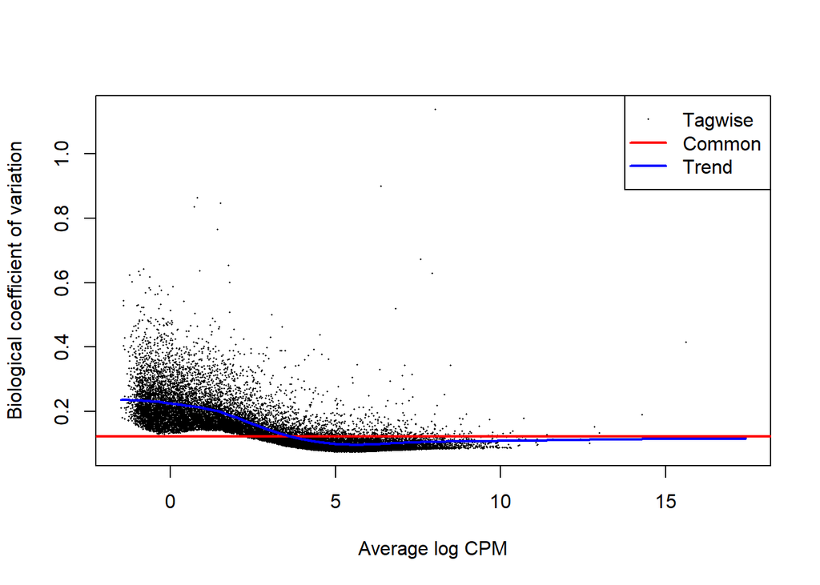

```r
y2e <- estimateDisp(y2e, design2, robust=TRUE)
plotBCV(y2e)
```

Using QL F-test instead of exact test

```r
fit2 <- glmQLFit(y2e, design2, robust=TRUE, coef=2)
fit2
```

```
## An object of class "DGEGLM"
## $coefficients
##                          DMSO         RA
## ENSMUSG00000000001  -9.137571 -0.2133040
## ENSMUSG00000000028  -9.666241 -0.1634116
## ENSMUSG00000000031  -8.952188  0.1488557
## ENSMUSG00000000037 -13.392034  0.2653655
## ENSMUSG00000000056 -10.977002 -0.2167971
## 18855 more rows ...
##
## $fitted.values
##                     DMSO_REP1  DMSO_REP2  DMSO_REP3    RA_REP1    RA_REP3
## ENSMUSG00000000001 2447.39255 2266.65197 1965.74957 1850.62315 1369.00634
## ENSMUSG00000000028 1442.40583 1335.88378 1158.54264 1146.48452  848.11679
## ENSMUSG00000000031 2945.90429 2728.34848 2366.15498 3199.82224 2367.08210
## ENSMUSG00000000037   34.61364   32.05741   27.80173   42.28266   31.27877
## ENSMUSG00000000056  388.78893  360.07676  312.27588  292.94009  216.70367
## 18855 more rows ...
##
## $deviance
## ENSMUSG00000000001 ENSMUSG00000000028 ENSMUSG00000000031 ENSMUSG00000000037
##          4.8288122          1.4833120          4.7584147          0.8598128
## ENSMUSG00000000056
##          3.3326147
## 18855 more elements ...
##
## $method
## [1] "oneway"
##
## $counts
##                    DMSO_REP1 DMSO_REP2 DMSO_REP3 RA_REP1 RA_REP3
## ENSMUSG00000000001      2456      2051      2147    2087    1191
## ENSMUSG00000000028      1524      1297      1126    1228     786
## ENSMUSG00000000031      3066      2765      2237    3683    2006
## ENSMUSG00000000037        41        29        25      39      34
## ENSMUSG00000000056       443       314       308     319     196
## 18855 more rows ...
##
## $unshrunk.coefficients
##                          DMSO         RA
```

[output cut: 72 more lines]

```
##           group lib.size norm.factors
## DMSO_REP1  DMSO 21759974    1.0458447
## DMSO_REP2  DMSO 20284700    1.0390542
## DMSO_REP3  DMSO 18350220    0.9961135
## RA_REP1      RA 21474245    0.9918929
## RA_REP3      RA 16918004    0.9313674
##
## $genes
##                    genes
## ENSMUSG00000000001 Gnai3
## ENSMUSG00000000028 Cdc45
## ENSMUSG00000000031   H19
## ENSMUSG00000000037 Scml2
## ENSMUSG00000000056  Narf
## 18855 more rows ...
```

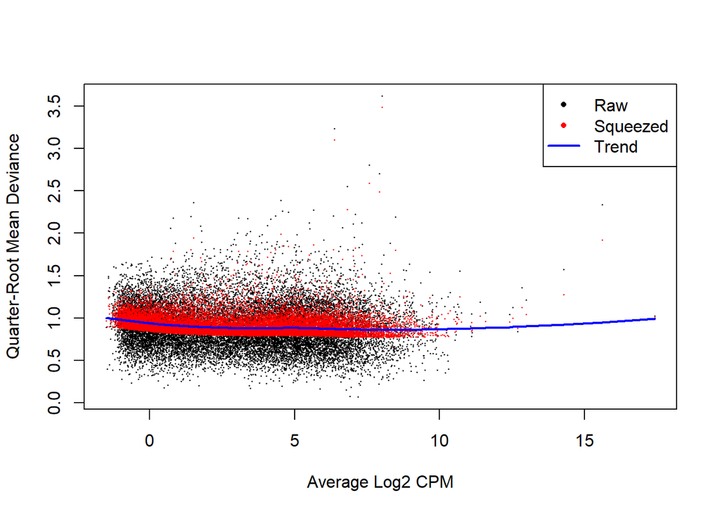

```r
plotQLDisp(fit2)
```

```r
qlf <- glmQLFTest(fit2)
topTags(qlf,30)
```

```
## Coefficient:  RA
##                       genes     logFC   logCPM         F       PValue
## ENSMUSG00000032125    Robo4  3.911500 5.078078 1389.2668 1.017163e-10
## ENSMUSG00000024427    Spry4  4.755755 5.302853 1262.4938 1.524011e-10
## ENSMUSG00000022094 Slc39a14  4.085386 5.417729 1060.8253 3.177665e-10
## ENSMUSG00000031169    Porcn  2.933436 5.316173  987.0917 4.306114e-10
## ENSMUSG00000030067    Foxp1  3.357846 4.339645  888.5229 6.709413e-10
## ENSMUSG00000030306    Tmtc1  3.261019 5.542656  846.2027 8.240807e-10
## ENSMUSG00000048752   Prss50  5.562865 2.929101  801.0181 1.038295e-09
## ENSMUSG00000029848    Stra8  4.881625 4.561568  771.6419 1.215113e-09
## ENSMUSG00000032232    Cgnl1  2.824931 5.764291  761.8688 1.282065e-09
## ENSMUSG00000038916    Soga3  3.907873 4.308853  697.0938 1.862959e-09
## ENSMUSG00000022012    Enox1  2.364619 5.402754  639.8123 2.670971e-09
## ENSMUSG00000091345   Col6a5  4.276671 3.505053  625.1610 2.943843e-09
## ENSMUSG00000021835     Bmp4  2.477943 4.405712  603.8251 3.405783e-09
## ENSMUSG00000035158     Mitf -2.448787 5.821292  603.3817 3.416299e-09
## ENSMUSG00000024987  Cyp26a1  9.627743 2.819867  601.5103 3.461124e-09
## ENSMUSG00000019989    Enpp3  2.673947 5.263142  595.7983 3.602513e-09
## ENSMUSG00000020183      Cpm  3.408733 3.268020  578.6631 4.071671e-09
## ENSMUSG00000031486   Adgra2  2.990952 5.120557  577.2778 4.112812e-09
## ENSMUSG00000037035    Inhbb  2.383981 4.595848  569.8498 4.342373e-09
## ENSMUSG00000004359     Spic -4.385813 4.501770  562.7021 4.578400e-09
## ENSMUSG00000017724     Etv4  3.484719 5.639434  558.2917 4.731962e-09
## ENSMUSG00000019960    Dusp6  3.003516 5.695660  545.1493 5.228862e-09
## ENSMUSG00000015653   Steap2  2.029576 5.944718  523.6121 6.190893e-09
## ENSMUSG00000030310   Slc6a1  2.162873 4.679484  518.0046 6.476465e-09
## ENSMUSG00000019944  Rhobtb1  4.753748 2.258628  492.3989 8.007699e-09
## ENSMUSG00000039115    Itga9  2.248423 4.797380  489.0706 8.238219e-09
## ENSMUSG00000034758     Tle6  2.466264 4.922589  472.2451 9.537513e-09
## ENSMUSG00000026389   Steap3  1.879806 5.581221  460.0171 1.064322e-08
## ENSMUSG00000000958   Slc7a7  2.041275 6.264832  452.6177 1.138961e-08
## ENSMUSG00000020661   Dnmt3a  1.737358 6.570242  448.8354 1.179609e-08
##                             FDR
## ENSMUSG00000032125 1.437142e-06
## ENSMUSG00000024427 1.437142e-06
## ENSMUSG00000022094 1.997692e-06
## ENSMUSG00000031169 2.030333e-06
## ENSMUSG00000030067 2.530791e-06
## ENSMUSG00000030306 2.590360e-06
## ENSMUSG00000048752 2.686638e-06
```

[output cut: 8 more lines]

```
## ENSMUSG00000019989 4.246462e-06
## ENSMUSG00000020183 4.249752e-06
## ENSMUSG00000031486 4.249752e-06
## ENSMUSG00000037035 4.249752e-06
## ENSMUSG00000004359 4.249752e-06
## ENSMUSG00000017724 4.249752e-06
## ENSMUSG00000019960 4.482561e-06
## ENSMUSG00000015653 5.076533e-06
## ENSMUSG00000030310 5.089422e-06
## ENSMUSG00000019944 5.975878e-06
## ENSMUSG00000039115 5.975878e-06
## ENSMUSG00000034758 6.662129e-06
## ENSMUSG00000026389 7.168969e-06
## ENSMUSG00000000958 7.407172e-06
## ENSMUSG00000020661 7.415810e-06
```

Count the number of genes with FDR < 5%

```r
results_edgeR <- topTags(qlf, n = nrow(y2e$counts), sort.by = "PValue")
head(results_edgeR$table)
```

```
##                       genes    logFC   logCPM         F       PValue
## ENSMUSG00000032125    Robo4 3.911500 5.078078 1389.2668 1.017163e-10
## ENSMUSG00000024427    Spry4 4.755755 5.302853 1262.4938 1.524011e-10
## ENSMUSG00000022094 Slc39a14 4.085386 5.417729 1060.8253 3.177665e-10
## ENSMUSG00000031169    Porcn 2.933436 5.316173  987.0917 4.306114e-10
## ENSMUSG00000030067    Foxp1 3.357846 4.339645  888.5229 6.709413e-10
## ENSMUSG00000030306    Tmtc1 3.261019 5.542656  846.2027 8.240807e-10
##                             FDR
## ENSMUSG00000032125 1.437142e-06
## ENSMUSG00000024427 1.437142e-06
## ENSMUSG00000022094 1.997692e-06
## ENSMUSG00000031169 2.030333e-06
## ENSMUSG00000030067 2.530791e-06
## ENSMUSG00000030306 2.590360e-06
```

```r
sum(results_edgeR$table$FDR < .05)
```

```
## [1] 4823
```

4823 genes with 5% FDR

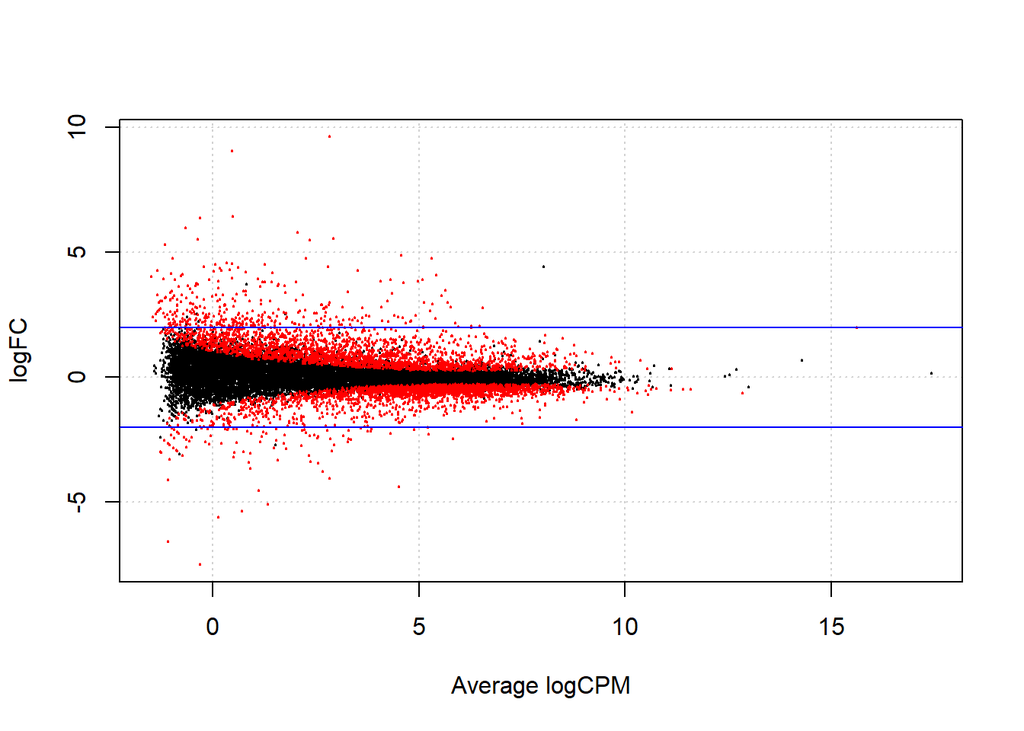

```r
plotSmear(qlf, de.tags = rownames(results_edgeR)[results_edgeR$table$FDR < .05])
abline(h = c(-2, 2), col = "blue")
```

### Heatmap

[figure not shown]

```r
#same color palette as above
# Set up colour vector for celltype variable
col.cell <- c("purple","orange")[group2]

etop.30 <- topTags(qlf,30)
etop.30.idx <- match(rownames(etop.30), rownames(y2e$counts))
etop.30.cpm <- y2e$counts[etop.30.idx,]
etop.30.df <- merge(etop.30, etop.30.cpm, by=0, all.x = TRUE, all.y= FALSE, sort=FALSE)

heatmap.2(as.matrix(etop.30.df[,8:12]), col=rev(morecols(50)), trace="none", main="Top 30 DEGs", ColSideColors=col.cell, scale="row", margins=c(2,10), labRow=top.30.df$genes, cexRow = 0.8, cexCol = 1, srtCol=0, adjCol = c(0.5,0.5))
```